# Mushroom Classification Supervised Machine Learning

```r
suppressPackageStartupMessages(library(tidyverse))
suppressPackageStartupMessages(library(tidymodels))
suppressPackageStartupMessages(library(ggplot2))
suppressPackageStartupMessages(library(reshape2))
```

To begin this project we need to first discover or create a dataset to use. After some time of searching, I discovered the Mushroom dataset which includes artificial descriptions of various mushrooms. These mushrooms are generally coded as poisonous or edible, while including their additional characteristics. This data is based upon the Audobon Society Field Guide. This guide claims that there are no easy rules for determining the edibility of a mushroom. Let’s see if that holds true for more advanced methods of supervised machine learning. For more information about this data, it can be found at the [UC Irvine Machine Learning Repository.](https://archive.ics.uci.edu/dataset/73/mushroom)

First, we first need to load in our data.

```r
data <- read.csv("data/mushrooms.csv")

head(data)
```

```
  class cap.shape cap.surface cap.color bruises odor gill.attachment
1     p         x           s         n       t    p               f
2     e         x           s         y       t    a               f
3     e         b           s         w       t    l               f
4     p         x           y         w       t    p               f
5     e         x           s         g       f    n               f
6     e         x           y         y       t    a               f
  gill.spacing gill.size gill.color stalk.shape stalk.root
1            c         n          k           e          e
2            c         b          k           e          c
3            c         b          n           e          c
4            c         n          n           e          e
5            w         b          k           t          e
6            c         b          n           e          c
  stalk.surface.above.ring stalk.surface.below.ring stalk.color.above.ring
```

[output cut: 20 more lines]

```r
summary(data)
```

```
    class            cap.shape         cap.surface         cap.color
 Length:8124        Length:8124        Length:8124        Length:8124
 Class :character   Class :character   Class :character   Class :character
 Mode  :character   Mode  :character   Mode  :character   Mode  :character
   bruises              odor           gill.attachment    gill.spacing
 Length:8124        Length:8124        Length:8124        Length:8124
 Class :character   Class :character   Class :character   Class :character
 Mode  :character   Mode  :character   Mode  :character   Mode  :character
  gill.size          gill.color        stalk.shape         stalk.root
 Length:8124        Length:8124        Length:8124        Length:8124
 Class :character   Class :character   Class :character   Class :character
 Mode  :character   Mode  :character   Mode  :character   Mode  :character
 stalk.surface.above.ring stalk.surface.below.ring stalk.color.above.ring
 Length:8124              Length:8124              Length:8124
 Class :character         Class :character         Class :character
 Mode  :character         Mode  :character         Mode  :character
 stalk.color.below.ring  veil.type          veil.color
 Length:8124            Length:8124        Length:8124
 Class :character       Class :character   Class :character
 Mode  :character       Mode  :character   Mode  :character
 ring.number         ring.type         spore.print.color   population
 Length:8124        Length:8124        Length:8124        Length:8124
 Class :character   Class :character   Class :character   Class :character
 Mode  :character   Mode  :character   Mode  :character   Mode  :character
   habitat
 Length:8124
 Class :character
 Mode  :character
```

Before we get too far, we should make sure we know what our column names are.

```r
colnames(data)
```

```
 [1] "class"                    "cap.shape"
 [3] "cap.surface"              "cap.color"
 [5] "bruises"                  "odor"
 [7] "gill.attachment"          "gill.spacing"
 [9] "gill.size"                "gill.color"
[11] "stalk.shape"              "stalk.root"
[13] "stalk.surface.above.ring" "stalk.surface.below.ring"
[15] "stalk.color.above.ring"   "stalk.color.below.ring"
[17] "veil.type"                "veil.color"
[19] "ring.number"              "ring.type"
[21] "spore.print.color"        "population"
[23] "habitat"
```

We know based on the data description that the column “class” is coded as e: edible and p: poisonous. This see what our distribution of mushrooms looks like.

```r
distribution <- table(data$class)
distribution
```

```
   e    p
4208 3916
```

```r
distribution[1] / (distribution[1] + distribution[2])
```

```
        e
0.5179714
```

```r
distribution[2] / (distribution[1] + distribution[2])
```

```
        p
0.4820286
```

This looks like a pretty even split so there probably isn’t much wrangling that needs to occur with this data. Let’s also check for any missing values in the data.

```r
anyNA(data)
```

```
[1] FALSE
```

We can see that there are no missing values in this dataset. Now we can better understand our data. What are the other columns coded as? We can use the table that we generate to compare with the provided coding information from the UCI Repository.

```r
data_long <- data %>% gather(data, "key", class:habitat)
colnames(data_long) <- c("group", "value")
data_long <- data_long[data_long$group != "class",]


ggplot(data_long) +
  geom_bar(aes(x = value, group = group)) +
  facet_wrap(~group, ncol = 4, scales = "free") +
  theme_minimal()
```

[figure not shown]

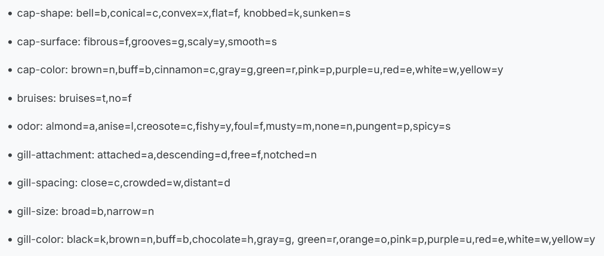

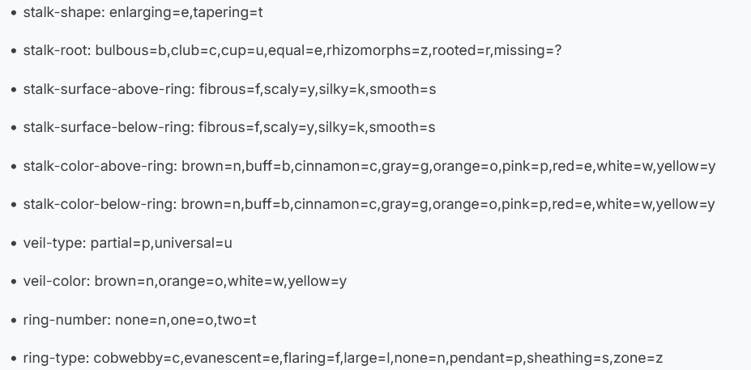

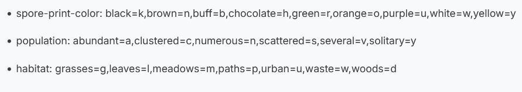

Now that we have seen our data, let’s remove the column for veil.type because it only has one factor. This isn’t useful for our model and should help simplify our data.

```r
### Remove veil type because it only has 1 factor
data <- subset(data, select = -c(veil.type))
```

We can also see that some of our variables are predominantly one value. Let’s take a closer look at these predictors to see if they might have an impact on our model if it is worth removing them in order to prevent an overly weighted predictor from impacting the model.

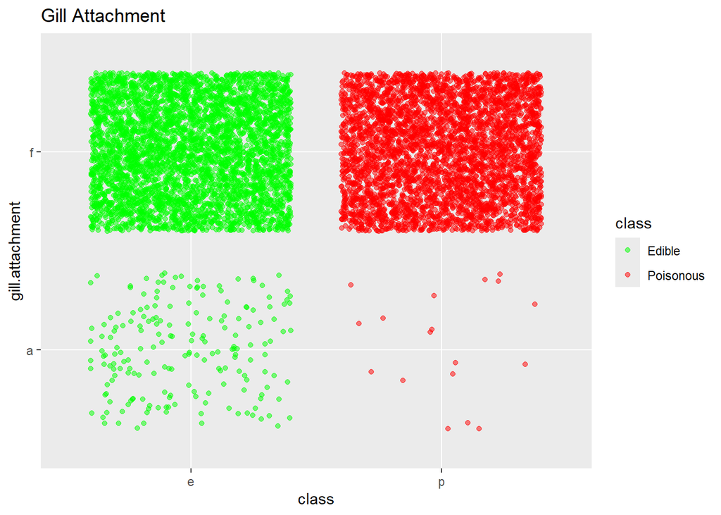

```r
ggplot(data, aes(x = class, y = gill.attachment, col = class)) +
  geom_jitter(alpha = 0.5) +
  ggtitle("Gill Attachment") +
  scale_color_manual(breaks = c("e", "p"),
                     labels = c("Edible", "Poisonous"),
                     values = c("green", "red"))
```

```r
table(data$class, data$gill.attachment)
```

```
       a    f
  e  192 4016
  p   18 3898
```

Here we can see a pretty even split between the edible and poisonous classes. There appears to be a tendency for attached veils to be more often edible rather than poisonous

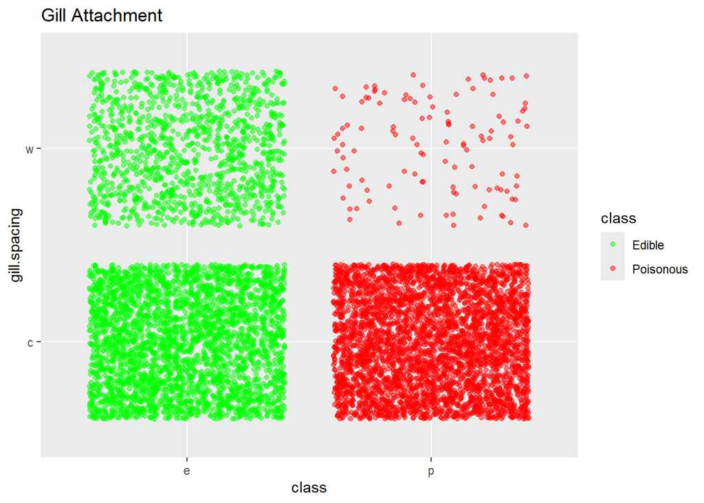

```r
ggplot(data, aes(x = class, y = gill.spacing, col = class)) +
  geom_jitter(alpha = 0.5) +
  ggtitle("Gill Attachment") +
  scale_color_manual(breaks = c("e", "p"),
                     labels = c("Edible", "Poisonous"),
                     values = c("green", "red"))
```

```r
table(data$class, data$gill.spacing)
```

```
       c    w
  e 3008 1200
  p 3804  112
```

This is also pretty split when considering gill spacing. Here we can see a tendency for crowded gills to be edible more often.

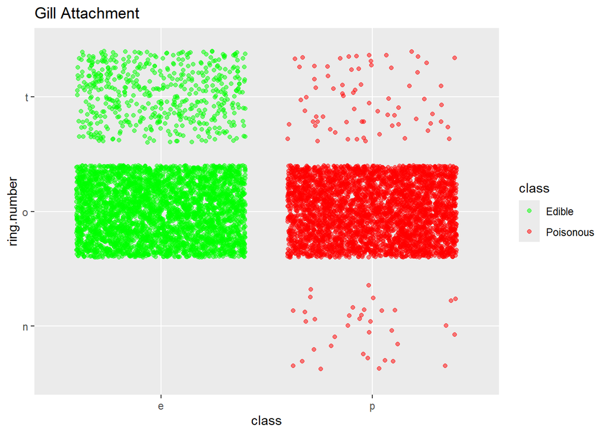

```r
ggplot(data, aes(x = class, y = ring.number, col = class)) +
  geom_jitter(alpha = 0.5) +
  ggtitle("Gill Attachment") +
  scale_color_manual(breaks = c("e", "p"),
                     labels = c("Edible", "Poisonous"),
                     values = c("green", "red"))
```

```r
table(data$class, data$ring.number)
```

```
       n    o    t
  e    0 3680  528
  p   36 3808   72
```

```r
data <- subset(data, select = -c(ring.number))
```

Here we can see a pretty big difference for mushrooms that have no ring numbers. This data might indicate that all mushrooms that have no rings would be poisonous but some research shows that this is not true. Therefore, I have removed this column from consideration in the model.

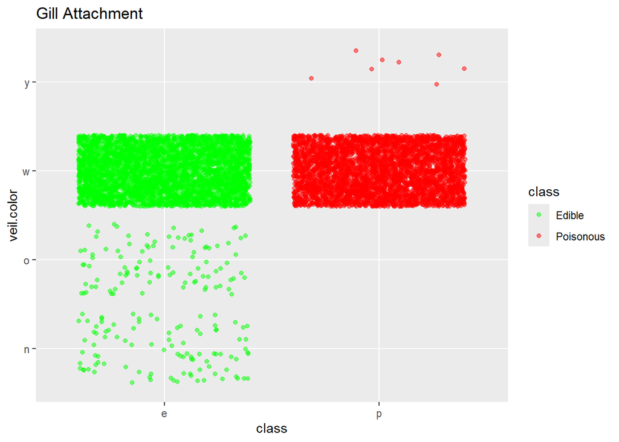

```r
ggplot(data, aes(x = class, y = veil.color, col = class)) +
  geom_jitter(alpha = 0.5) +
  ggtitle("Gill Attachment") +
  scale_color_manual(breaks = c("e", "p"),
                     labels = c("Edible", "Poisonous"),
                     values = c("green", "red"))
```

```r
table(data$class, data$veil.color)
```

```
       n    o    w    y
  e   96   96 4016    0
  p    0    0 3908    8
```

```r
data <- subset(data, select = -c(veil.color))
```

In veil color we also see strong weighting towards a specific class based on the veil color. Therefore, I have removed this column from consideration in the model as well.

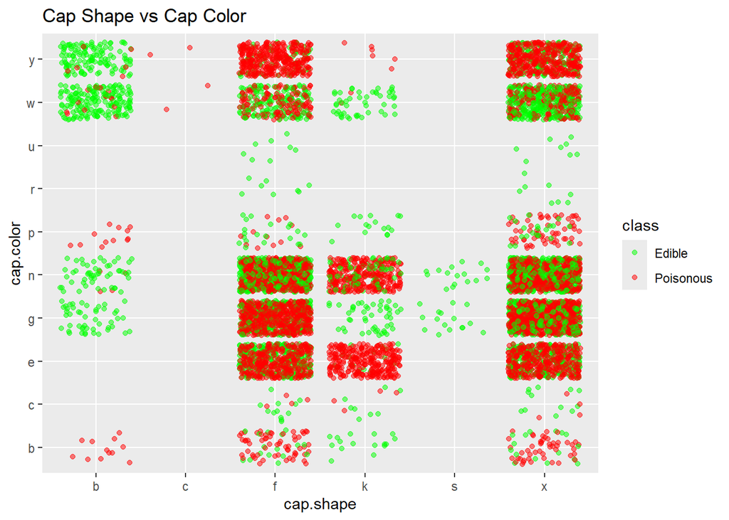

```r
ggplot(data, aes(x = cap.shape, y = cap.color, col = class)) +
  geom_jitter(alpha = 0.5) +
  ggtitle("Cap Shape vs Cap Color") +
  scale_color_manual(breaks = c("e", "p"),
                     labels = c("Edible", "Poisonous"),
                     values = c("green", "red"))
```

It looks like this is mostly true but maybe we should avoid the pink and buff colored mushrooms. We can continue with this style graph to get a better idea of how our data looks. Based on some research, we know that odor can also be a strong indicator. Let’s see how this looks in a graph.

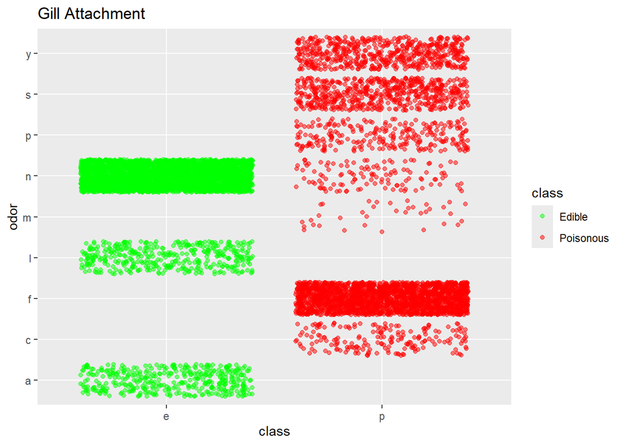

```r
ggplot(data, aes(x = class, y = odor, col = class)) +
  geom_jitter(alpha = 0.5) +
  ggtitle("Gill Attachment") +
  scale_color_manual(breaks = c("e", "p"),
                     labels = c("Edible", "Poisonous"),
                     values = c("green", "red"))
```

```r
table(data$class, data$odor)
```

```
       a    c    f    l    m    n    p    s    y
  e  400    0    0  400    0 3408    0    0    0
  p    0  192 2160    0   36  120  256  576  576
```

It would appear that odor is a strong separator between out two classes. This might be something to remember as we start examining some models.

At this point, we have a pretty good idea of how our data looks. We can look further into the data but we don’t want our knowledge of the data to influence our models too much. To begin with the models, we need to separate our data into a training set and a test set. This will allow us to test the models to get a better idea of accuracy. We will use a simple 80-20 split to do this.

```r
ndx <- sample(1:nrow(data), round(0.8*nrow(data)))

train <- data[ndx,]
test <- data[-ndx,]
```